# Practical Machine Learning @JHU

Astrid Hanghøj

3 aug 2016

## Problem formulation

The goal of your project is to predict the manner in which they did the exercise. This is the “classe” variable in the training set. You may use any of the other variables to predict with. You should create a report describing how you built your model, how you used cross validation, what you think the expected out of sample error is, and why you made the choices you did. You will also use your prediction model to predict 20 different test cases

## Description

How model was build: Participants were asked to perform one set of 10 repetitions of the Unilateral Dumbbell Biceps Curl in 5 different fashions: - exactly according to the specification (Class A) - throwing the elbows to the front (Class B) - lifting the dumbbell only halfway (Class C) - lowering the dumbbell only halfway (Class D) - throwing the hips to the front (Class E)

I’ve decided to just compare two models: decision tree and randomforest from the course curriculum.

Cross validation: The large training set (n=19622) allows for dividing the training set into two folds for cross-validation.

Expected out-of-sample error: 1-accuracy in the cross-validation data.

To save on compute time (slow convergence), I’ve done some cleanup of nearzero variance variables using caret package.

## Loading libraries

Loading relevant libs

```r
rm(list = ls())
setwd("P:/Coursera/Machine Learning")

library("caret")
library("randomForest")
```

```r
library("rpart")
library("rpart.plot")
```

### Download and load data

Download data

```r
download.file("https://d396qusza40orc.cloudfront.net/predmachlearn/pml-training.csv", "pml-training.csv")
download.file("https://d396qusza40orc.cloudfront.net/predmachlearn/pml-testing.csv", "pml-testing.csv")

trainingdata<-read.csv("pml-training.csv")
testdata<-read.csv("pml-testing.csv")

set.seed(1)
```

## Data cleanup

```r
# Delete columns with all missing values
trainingdata<-trainingdata[,colSums(is.na(trainingdata)) == 0]
testdata <-testdata[,colSums(is.na(testdata)) == 0]

# Drop irrelevant vars
trainingdata<-trainingdata[,-c(1:7)]
testdata <-testdata[,-c(1:7)]

# Remove vars with lots of NA
nearzero <- nearZeroVar(trainingdata, saveMetrics = TRUE)
trainingdata <- trainingdata[, !nearzero$nzv]
```

## Plot data

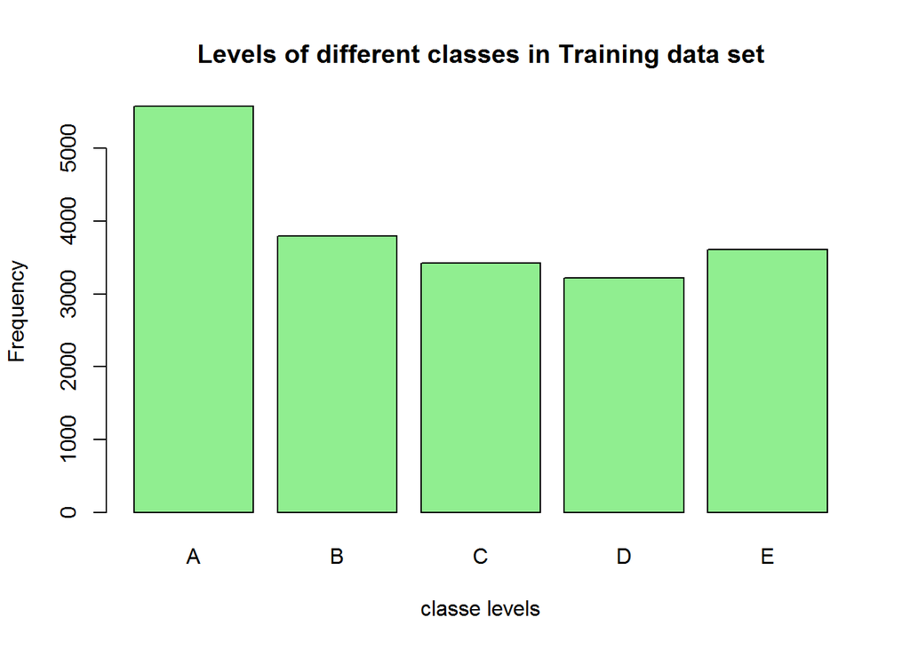

```r
plot(trainingdata$classe, col="lightgreen", main="Levels of different classes in Training data set", xlab="classe levels", ylab="Frequency")
```

## Splitting data for 2-fold cross validation

```r
sampling <- createDataPartition(y=trainingdata$classe, p=0.7, list=FALSE)
trainingdata_trainfold <- trainingdata[sampling, ]
trainingdata_testfold <- trainingdata[-sampling, ]
```

## Descision tree (DT)

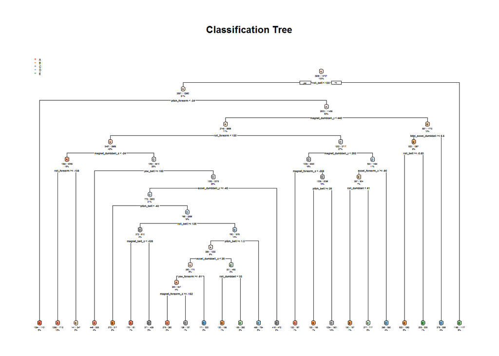

```r
m_decisiontree <- rpart(classe ~ ., data=trainingdata_trainfold, method="class")

# Predicting:
p_descisiontree <- predict(m_decisiontree, trainingdata_testfold, type = "class")

# Plot of the Decision Tree
rpart.plot(m_decisiontree, main="Classification Tree", extra=102, under=TRUE, faclen=0)
```

```r
# Test results on our subTesting data set:
confusionMatrix(p_descisiontree, trainingdata_testfold$classe)
```

```
## Confusion Matrix and Statistics
##
##           Reference
## Prediction    A    B    C    D    E
##          A 1473  160   24   44   15
##          B   55  699   56   73  101
##          C   57  121  818  161  132
##          D   56   82   60  609   53
##          E   33   77   68   77  781
##
## Overall Statistics
##
##                Accuracy : 0.7443
##                  95% CI : (0.7329, 0.7554)
##     No Information Rate : 0.2845
##     P-Value [Acc > NIR] : < 2.2e-16
##
##                   Kappa : 0.6764
##  Mcnemar's Test P-Value : < 2.2e-16
##
## Statistics by Class:
##
##                      Class: A Class: B Class: C Class: D Class: E
## Sensitivity            0.8799   0.6137   0.7973   0.6317   0.7218
## Specificity            0.9423   0.9399   0.9031   0.9490   0.9469
## Pos Pred Value         0.8584   0.7104   0.6346   0.7081   0.7539
## Neg Pred Value         0.9518   0.9102   0.9547   0.9294   0.9379
## Prevalence             0.2845   0.1935   0.1743   0.1638   0.1839
## Detection Rate         0.2503   0.1188   0.1390   0.1035   0.1327
## Detection Prevalence   0.2916   0.1672   0.2190   0.1461   0.1760
## Balanced Accuracy      0.9111   0.7768   0.8502   0.7904   0.8344
```

## Random forest (RF)

```r
m_randomforest <- randomForest(classe ~. , data=trainingdata_trainfold, method="class")

# Predicting:
p_randomforest <- predict(m_randomforest, trainingdata_testfold, type = "class")

# Test results on subTesting data set:
confusionMatrix(p_randomforest, trainingdata_testfold$classe)
```

```
## Confusion Matrix and Statistics
##
##           Reference
## Prediction    A    B    C    D    E
##          A 1670    2    0    0    0
##          B    3 1136    7    0    0
##          C    0    1 1018    4    0
##          D    0    0    1  958    2
##          E    1    0    0    2 1080
##
## Overall Statistics
##
##                Accuracy : 0.9961
##                  95% CI : (0.9941, 0.9975)
##     No Information Rate : 0.2845
##     P-Value [Acc > NIR] : < 2.2e-16
##
##                   Kappa : 0.9951
##  Mcnemar's Test P-Value : NA
##
## Statistics by Class:
##
##                      Class: A Class: B Class: C Class: D Class: E
## Sensitivity            0.9976   0.9974   0.9922   0.9938   0.9982
## Specificity            0.9995   0.9979   0.9990   0.9994   0.9994
## Pos Pred Value         0.9988   0.9913   0.9951   0.9969   0.9972
## Neg Pred Value         0.9991   0.9994   0.9984   0.9988   0.9996
## Prevalence             0.2845   0.1935   0.1743   0.1638   0.1839
## Detection Rate         0.2838   0.1930   0.1730   0.1628   0.1835
## Detection Prevalence   0.2841   0.1947   0.1738   0.1633   0.1840
## Balanced Accuracy      0.9986   0.9976   0.9956   0.9966   0.9988
```

## Modeling the full test data

In the following we predict the test cases for the final quiz.

```r
m_final<-randomForest(classe ~. , data=trainingdata, method="class")

p_final <- predict(m_final, testdata, type = "class")
p_final
```

```
##  1  2  3  4  5  6  7  8  9 10 11 12 13 14 15 16 17 18 19 20
##  B  A  B  A  A  E  D  B  A  A  B  C  B  A  E  E  A  B  B  B
## Levels: A B C D E
```